# Lab 3 - Landcover patterns and change

```r
rm(list=ls())
require(tidyverse)
require(terra)
require(FedData)
require(sf)
require(tidyterra)
require(landscapemetrics)
```

Today we’re going to be talking about measuring patterns in rasters. We’re focusing on landcover, but as we’ve discussed, there is no reason that these ideas couldn’t be translated to climatic variables, water bodies, elevations, etc. We’re going to be relying heavily on the landscapemetrics R package (https://r-spatialecology.github.io/landscapemetrics/index.html). If you’ve ever used the FRAGSTATS software, this package is meant to be a sort of replacement that covers most of the same functions available in FRAGSTATS, but does so right in R so that you can do it all (landscape analysis and subsequent statistical analyses) in a single environment.

I’ve zoomed in on one of the study areas in Alabama that we used in the previous lab. Here we are loading the boundary of that study area and downloading NLCD data relevant to it. Note that you may find the get_nlcd() function very handy in your work going forward, as it brings NLCD data straight in without you having to download the entire dataset (nationwide) to your computer.

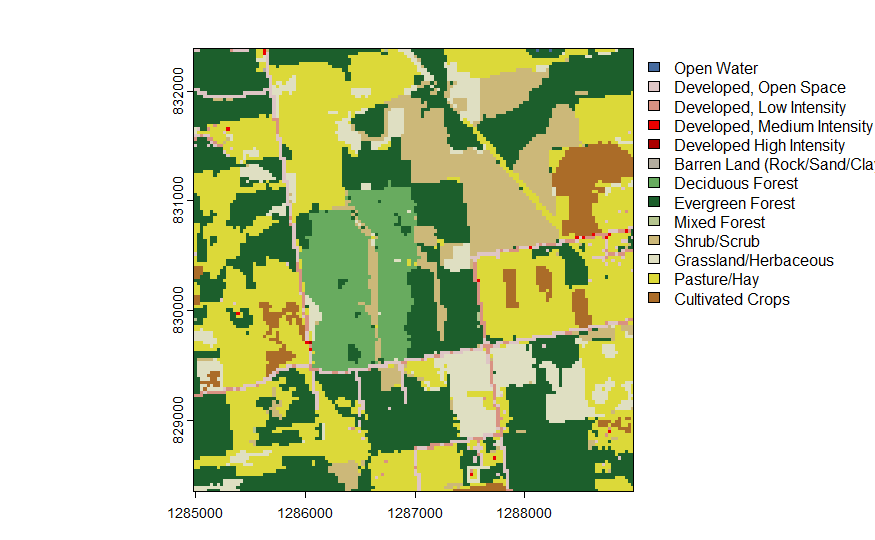

```r
studyArea = st_read('/vsicurl/https://github.com/ValenteJJ/SpatialEcology/raw/main/Week4/studyArea.shp')
nlcd = get_nlcd(studyArea, label='AlLandscape', year=2011)

# values(nlcd) = as.character(values(nlcd))

plot(nlcd)
```

For our purposes, we are going to simplify this raster by condensing some of these land cover categories.

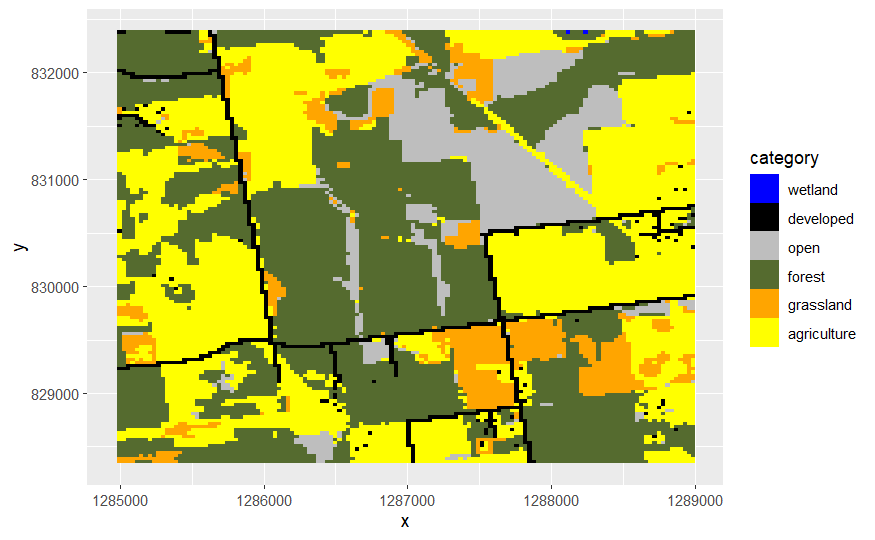

```r
nlcdSimple = nlcd
nlcdSimple[nlcdSimple==11] = 1 #Wet areas are a 1 now
nlcdSimple[nlcdSimple %in% c(21, 22, 23, 24)] = 2 #All developed areas are 2
nlcdSimple[nlcdSimple %in% c(31, 52)] = 3 #Barren land and shrub/scrub are 3
nlcdSimple[nlcdSimple %in% c(41,42,43)] = 4 #All forest types are 4
nlcdSimple[nlcdSimple == 71] = 5 #Grassland is 5
nlcdSimple[nlcdSimple %in% c(81,82)] = 6 #And agriculture is 6

#Give these numbers category names
tmp = data.frame('ID' = c(1, 2, 3, 4, 5, 6),
                 'category' = c('wetland', 'developed', 'open', 'forest', 'grassland', 'agriculture'))
nlcdSimple = categories(nlcdSimple, value=tmp)

#And plot the new raster
ggplot(nlcdSimple, aes(x=x, y=y, fill=category)) +
  geom_raster()+
  scale_fill_manual(values=c('blue', 'black', 'gray', 'darkolivegreen', 'orange', 'yellow'))
```

As always, if we want to look at characteristics of this raster, we can do so

```r
levels(nlcdSimple)
```

| ID | category |
| --- | --- |
| 1 | wetland |
| 2 | developed |
| 3 | open |
| 4 | forest |
| 5 | grassland |
| 6 | agriculture |

```
NA
```

# Patch-level metrics

Patch-level metrics are (as the name implies) metrics that are measured as pertain to individual patches.

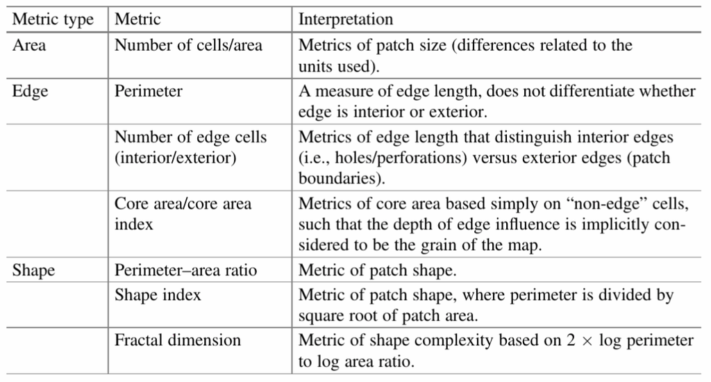

[figure not shown]

However, before we can calculate patch-level metrics, we first need to define the patches. We’re going to focus on forest here, so let’s categorize the landscape as forest/non-forest.

```r
forest = nlcdSimple %>%
  setValues(NA)

forest[nlcdSimple ==4] = 1

plot(forest)
```

[output not shown]

### Rook or queen?

Another critical decision we need to make is what constitutes a patch. This brings us to the 4-neighbor or 8-neighbor decision (also called rook or queen). Basically the question is whether two cells touching at the corner constitute the same patch or different patches. There is no universally correct answer here, but rather you’re going to need to consider the properties of the raster and the biological question at hand to make a justifiable decision. For the purposes of our exercise, we are going to use the queen rule. The patches() function in the terra package identifies “clumps” of like cells that can be considered identical patches. All cells in a clump are given the same patch ID, and cells in different patches receive different patch ID variables.

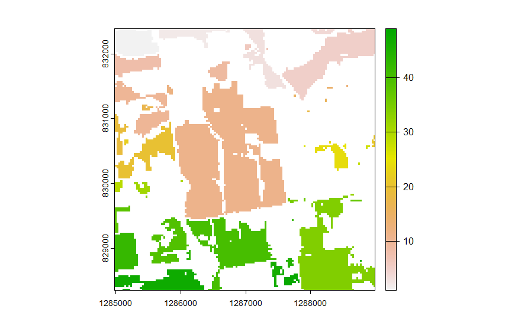

```r
forestPatchId = patches(forest, directions=8, zeroAsNA=T, allowGaps=F)

plot(forestPatchId)
```

The package landscapemetrics has tons and tons of functions. You can find details for the package here (https://cran.r-project.org/web/packages/landscapemetrics/index.html). In fact, it has its own publication (https://nsojournals.onlinelibrary.wiley.com/doi/epdf/10.1111/ecog.04617). Most of the functions have a 3-part name. The first part is “lsm” which stands for “landscape metrics.” The second part tells you which level the function applies to (p for patch, c for class, or l for landscape). The last part is an abbreviation for the metric (e.g., enn for euclidean nearest neighbor distance). Let’s look at how one of these functions works. We’ll start with the patch-level metric patch area.

```r
patchArea = lsm_p_area(forest, directions=8)

patchArea
```

| layer | level | class | id | metric | value |
| --- | --- | --- | --- | --- | --- |
| 1 | patch | 1 | 1 | area | 24.30 |
| 1 | patch | 1 | 2 | area | 15.84 |
| 1 | patch | 1 | 3 | area | 25.29 |
| 1 | patch | 1 | 4 | area | 5.31 |
| 1 | patch | 1 | 5 | area | 25.02 |
| 1 | patch | 1 | 6 | area | 1.71 |
| 1 | patch | 1 | 7 | area | 2.97 |
| 1 | patch | 1 | 8 | area | 18.81 |
| 1 | patch | 1 | 9 | area | 28.17 |
| 1 | patch | 1 | 10 | area | 0.36 |

[output cut: 39 more lines]

Note there are 49 rows here. Each row represents a unique forest patch in this landscape and we are seeing the output of the size of each of those patches (in ha) under the “value” column. We can calculate many patch metrics this way. For example, instead of area, we could look at core area (area of the patch not touching an edge).

```r
patchCore = lsm_p_core(forest, directions=8)

patchCore
```

| layer | level | class | id | metric | value |
| --- | --- | --- | --- | --- | --- |
| 1 | patch | 1 | 1 | core | 18.63 |
| 1 | patch | 1 | 2 | core | 10.26 |
| 1 | patch | 1 | 3 | core | 14.94 |
| 1 | patch | 1 | 4 | core | 1.08 |
| 1 | patch | 1 | 5 | core | 14.76 |
| 1 | patch | 1 | 6 | core | 0.45 |
| 1 | patch | 1 | 7 | core | 0.00 |
| 1 | patch | 1 | 8 | core | 13.86 |
| 1 | patch | 1 | 9 | core | 17.91 |
| 1 | patch | 1 | 10 | core | 0.00 |

[output cut: 39 more lines]

Note that although we still have 49 rows (one per patch), some of the values for core area are 0, indicating all cells in that patch touch the edge. We could also look at

```r
patchEnn = lsm_p_enn(forest, directions=8)

patchEnn
```

| layer | level | class | id | metric | value |
| --- | --- | --- | --- | --- | --- |
| 1 | patch | 1 | 1 | enn | 60.00000 |
| 1 | patch | 1 | 2 | enn | 60.00000 |
| 1 | patch | 1 | 3 | enn | 60.00000 |
| 1 | patch | 1 | 4 | enn | 60.00000 |
| 1 | patch | 1 | 5 | enn | 60.00000 |
| 1 | patch | 1 | 6 | enn | 60.00000 |
| 1 | patch | 1 | 7 | enn | 60.00000 |
| 1 | patch | 1 | 8 | enn | 60.00000 |
| 1 | patch | 1 | 9 | enn | 60.00000 |
| 1 | patch | 1 | 10 | enn | 60.00000 |

[output cut: 39 more lines]

This is now reporting the edge-to-edge distance between each patch and its next nearest neighbor patch in meters. We can also calculate the perimeter of each patch, again in meters.

```r
patchPerim = lsm_p_perim(forest, directions=8)

patchPerim
```

| layer | level | class | id | metric | value |
| --- | --- | --- | --- | --- | --- |
| 1 | patch | 1 | 1 | perim | 2340 |
| 1 | patch | 1 | 2 | perim | 2460 |
| 1 | patch | 1 | 3 | perim | 5400 |
| 1 | patch | 1 | 4 | perim | 1920 |
| 1 | patch | 1 | 5 | perim | 4860 |
| 1 | patch | 1 | 6 | perim | 600 |
| 1 | patch | 1 | 7 | perim | 1380 |
| 1 | patch | 1 | 8 | perim | 1920 |
| 1 | patch | 1 | 9 | perim | 4320 |
| 1 | patch | 1 | 10 | perim | 300 |

[output cut: 39 more lines]

And we can calculate shape metrics like the perimeter-area-ratio.

```r
patchPara = lsm_p_para(forest, directions=8)

patchPara
```

| layer | level | class | id | metric | value |
| --- | --- | --- | --- | --- | --- |
| 1 | patch | 1 | 1 | para | 0.009629630 |
| 1 | patch | 1 | 2 | para | 0.015530303 |
| 1 | patch | 1 | 3 | para | 0.021352313 |
| 1 | patch | 1 | 4 | para | 0.036158192 |
| 1 | patch | 1 | 5 | para | 0.019424460 |
| 1 | patch | 1 | 6 | para | 0.035087719 |
| 1 | patch | 1 | 7 | para | 0.046464646 |
| 1 | patch | 1 | 8 | para | 0.010207337 |
| 1 | patch | 1 | 9 | para | 0.015335463 |
| 1 | patch | 1 | 10 | para | 0.083333333 |

[output cut: 39 more lines]

# Class-level metrics

Class-level metrics summarize information about the entire class within a landscape of interest. Such metrics may or may not be based on our previous patch delineations. Because we were just looking at patch-based metrics, let’s summarize such information at the class level.

### Patch-based

Here, instead of working with the forest raster, we’re going to go back and use the nlcdSimple raster. This allows us to calculate class-level summaries for all classes simultaneously. Let’s start by examining the mean and standard deviation of patch sizes.

```r
#The functions annoyingly summarize by class instead of category, so we have to merge the category values back in after the summary.

classCats = data.frame('class' = c(1, 2, 3, 4, 5, 6),
                 'category' = c('wetland', 'developed', 'open', 'forest', 'grassland', 'agriculture'))



lsm_c_area_mn(nlcdSimple, directions=8) %>%
  left_join(classCats, by='class')
```

| layer | level | class | id | metric | value | category |
| --- | --- | --- | --- | --- | --- | --- |
| 1 | class | 1 | NA | area_mn | 0.090000 | wetland |
| 1 | class | 2 | NA | area_mn | 1.138235 | developed |
| 1 | class | 3 | NA | area_mn | 2.962373 | open |
| 1 | class | 4 | NA | area_mn | 13.650612 | forest |
| 1 | class | 5 | NA | area_mn | 2.240847 | grassland |
| 1 | class | 6 | NA | area_mn | 10.067797 | agriculture |

```r
lsm_c_area_sd(nlcdSimple, directions=8) %>%
  left_join(classCats, by='class')
```

| layer | level | class | id | metric | value | category |
| --- | --- | --- | --- | --- | --- | --- |
| 1 | class | 1 | NA | area_sd | 0.000000 | wetland |
| 1 | class | 2 | NA | area_sd | 7.140984 | developed |
| 1 | class | 3 | NA | area_sd | 11.691167 | open |
| 1 | class | 4 | NA | area_sd | 35.959160 | forest |
| 1 | class | 5 | NA | area_sd | 4.642781 | grassland |
| 1 | class | 6 | NA | area_sd | 26.473516 | agriculture |

Note that forest patches have the greatest mean patch size, but also the greatest standard deviation among patch sizes compared to all of the other classes in the landscape. We can similarly calculate the mean and standard deviation of the core patch sizes for all classes on the landscape.

```r
lsm_c_core_mn(nlcdSimple, directions=8) %>%
  left_join(classCats, by='class')
```

| layer | level | class | id | metric | value | category |
| --- | --- | --- | --- | --- | --- | --- |
| 1 | class | 1 | NA | core_mn | 0.000000000 | wetland |
| 1 | class | 2 | NA | core_mn | 0.003529412 | developed |
| 1 | class | 3 | NA | core_mn | 1.850338983 | open |
| 1 | class | 4 | NA | core_mn | 9.547346939 | forest |
| 1 | class | 5 | NA | core_mn | 1.003728814 | grassland |
| 1 | class | 6 | NA | core_mn | 6.829322034 | agriculture |

```r
lsm_c_core_sd(nlcdSimple, directions=8) %>%
  left_join(classCats, by='class')
```

| layer | level | class | id | metric | value | category |
| --- | --- | --- | --- | --- | --- | --- |
| 1 | class | 1 | NA | core_sd | 0.00000000 | wetland |
| 1 | class | 2 | NA | core_sd | 0.02520504 | developed |
| 1 | class | 3 | NA | core_sd | 9.24585312 | open |
| 1 | class | 4 | NA | core_sd | 28.91805202 | forest |
| 1 | class | 5 | NA | core_sd | 3.08634864 | grassland |
| 1 | class | 6 | NA | core_sd | 19.66446619 | agriculture |

**Why are the mean and standard deviation of core patch size for wetlands both 0?**

We can calculate the mean and standard deviation of nearest neighbor distance.

```r
lsm_c_enn_mn(nlcdSimple) %>%
  left_join(classCats, by='class')
```

| layer | level | class | id | metric | value | category |
| --- | --- | --- | --- | --- | --- | --- |
| 1 | class | 1 | NA | enn_mn | 120.00000 | wetland |
| 1 | class | 2 | NA | enn_mn | 109.01191 | developed |
| 1 | class | 3 | NA | enn_mn | 147.94124 | open |
| 1 | class | 4 | NA | enn_mn | 83.78503 | forest |
| 1 | class | 5 | NA | enn_mn | 156.36138 | grassland |
| 1 | class | 6 | NA | enn_mn | 86.89419 | agriculture |

And we can go on and on. For example, we can quantify cohesion of patches in each class.

```r
lsm_c_cohesion(nlcdSimple) %>%
  left_join(classCats, by='class')
```

| layer | level | class | id | metric | value | category |
| --- | --- | --- | --- | --- | --- | --- |
| 1 | class | 1 | NA | cohesion | 0.00000 | wetland |
| 1 | class | 2 | NA | cohesion | 95.62027 | developed |
| 1 | class | 3 | NA | cohesion | 92.35085 | open |
| 1 | class | 4 | NA | cohesion | 96.39308 | forest |
| 1 | class | 5 | NA | cohesion | 86.76152 | grassland |
| 1 | class | 6 | NA | cohesion | 96.45671 | agriculture |

### Not patch-based

There are also plenty of metrics that are not related to patch delineations themselves. For example, we could simply calculate the total area of each habitat type in the landscape.

```r
lsm_c_ca(nlcdSimple) %>%
  left_join(classCats, by='class')
```

| layer | level | class | id | metric | value | category |
| --- | --- | --- | --- | --- | --- | --- |
| 1 | class | 1 | NA | ca | 0.18 | wetland |
| 1 | class | 2 | NA | ca | 58.05 | developed |
| 1 | class | 3 | NA | ca | 174.78 | open |
| 1 | class | 4 | NA | ca | 668.88 | forest |
| 1 | class | 5 | NA | ca | 132.21 | grassland |
| 1 | class | 6 | NA | ca | 594.00 | agriculture |

[output not shown]

And we can aggregate information about the distribution of edges for each class type with, for example, the edge density metric which reports meters of edge per hectare of each habitat type.

| layer | level | class | id | metric | value | category |
| --- | --- | --- | --- | --- | --- | --- |
| 1 | class | 1 | NA | ed | 0.1105583 | wetland |
| 1 | class | 2 | NA | ed | 25.2810024 | developed |
| 1 | class | 3 | NA | ed | 22.9408513 | open |
| 1 | class | 4 | NA | ed | 54.5052515 | forest |
| 1 | class | 5 | NA | ed | 24.7650636 | grassland |
| 1 | class | 6 | NA | ed | 53.3812419 | agriculture |

# Cell-level metrics

```r
tmp = distance(forest, target=1)

plot(forest)
```

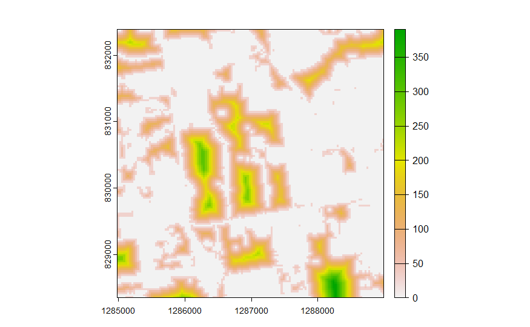

```r
plot(tmp)
```

```r
tmp = focalMat(forest, 200, type='circle', fillNA=FALSE)

forestWith0 = forest
forestWith0[is.na(forestWith0)] = 0

for200m = focal(forestWith0, tmp, fun='sum')

plot(forest)
```

[figure not shown]

```r
plot(for1km)
```

[output not shown]

```r
ggplot(patchArea, aes(x=value))+
  geom_histogram(binwidth=10)

mean(patchArea$value)
sd(patchArea$value)
```

[output not shown]